# Final Project - BIOS 6643

Dominic Adducci

2023-12-09

# Introduction

Sarcoidosis is a potentially lethal disease with ~ 25,000 new cases diagnosed in the United States each year. The disease is characterized by granulomas, and the vast majority (90%) of cases primarily affect the lung. Currently, the standard in care for assessing sarcoidosis are lung images utilizing computed tomography (CT). While this method provides better characterizing of abnormalities compared to chest x-rays there are two primary problems; 1.) CT is primarily based on visual assessment, resulting in high inter- and intra-rater variation, and 2.) these visual assessments are not strongly predictive of disease course. Recently, a new method to better quantify measures of lung CT has been developed utilizing variograms. Variograms are a standard geostatistical too for measuring and modelling spatial covariance within an image, as well as spatial process as a function of distance between points.

Variogram data is typically represented by three parameters: 1.) the sill, 2.) the range, and 3.) the nugget. The sill is the overall variation present in an image, the range represents the spatial scale of correlation, and the nugget is the variation due to measurement error. For sufficiently high resolution images the nugget is 0, which will be assumed for this analysis. The location of each individual scan is represented by the normalized slice variable spanning 0 to 1, corresponding to the bottom and top of the lung respectively.

The purpose of this analysis is to answer two primary questions of interest:

*Should race be included as a demographic feature that is adjusted for?*

*How do clinical measures of disease associate with the lungs after adjusting for demographics?*

There are six total clinical measures of disease. Three of these are PFT measurements: FEV1 (Forced Expiratory Volume in 1 second), FVC (Forced Vital Capacity), and FEV1/FVC ratio (provided as a fraction). The other three are VAS (Visual Assessment Scores): fibrosis, mediastinal lymphadenopathy, and traction bronchiectasis. Demographics other than race are BMI, age, sex, and height. Analysis will involve comparing models with and without race to determine the impact of including this as a demographic feature, and plots will be presented to illustrated trends in clinical features for both sill and range. Additionally, further research on the ethical and clinical/scientific justification for inclusion of race as a predictor in sarcoidosis was performed.

# Methods

### Data

The data for this analysis was compiled from two main sources, clinical measurements and variogram measurements. The clinical measurements provided the demographic data and the PFT and VAS measurements, and included 368 subjects. Cleaning the clinical data involved several steps. For simplicity in modeling VAS measurements were considered a binary indicating presence of the condition or no presence of the condition. Both traction bronchiectasis and mediastinal lymphadenopathy had four potential levels, which were then collapsed into binary indicators. Fibrosis was already a binary variable, meaning this step was not necessary for this variable. The construction of the race variable involved combining the provided race and ethnicity variables. The race categories initially had 6 possible options, Black or African American, American Indian or Alaskan Native, white, multi-racial or no primary race, Asian, and unknown. The ethnicity variable denoted whether a subject was Hispanic or not Hispanic. The race variable used in this analysis first involved separating white subjects into Hispanic white and non-Hispanic white. After this race was collapsed into three categories: 1.) non-Hispanic white, 2.) Black or African American, 3.) and other, which incorporated American Indian or Alaskan Native, multi-racial or no primary race, Asian, unknown, and Hispanic white. Two important features are that subjects who were missing race/ethnicity data were considered “NA”, which is distinct from the “unknown” category, and the majority of subjects were non-Hispanic white, followed by Black or African American. The composite category of “other” had the smallest amount of subjects.

Variogram data included information regarding the subject ID for each measurement, as well as which lung each measurement came from. Variogram measurements had three components, the range, the psill, and the slice normalized variable, which indicated location in the lung. Values closer to 0 correspond to the bottom of the lung, and values closer to 1 correspond to the top of the lung. For this analysis normalized slice values between 0.1 and 0.9 were used to avoid measurement variations of the top and bottom-most portion of scans. In general each subject had 50 slices per lung, meaning a total of 100 scans per subject. Two subjetc were dropped during initial data cleaning, one due to an outlier in the range measurement (> 300), and another due to missing data on the left lung. Out of the original 342 subject 340 were kept after dropping these two. Lastly, psill and range were log transformed due to prominant right-skew in the distribution of each.

### Fibrosis

Summary of Models for Fibrosis

| Term | Left Lung Estimate | Left Lung SE | Left Lung P-Value | Left Lung EDF | Left Lung Ref. DF | Right Lung Estimate | Right Lung SE | Right Lung P-Value | Right Lung EDF | Right Lung Ref. DF |
| --- | --- | --- | --- | --- | --- | --- | --- | --- | --- | --- |
| **Outcome: Psill \| With Race** |  |  |  |  |  |  |  |  |  |  |
| Intercept | 10.25968 | 0.39775 | <2e-16 | NA | NA | 10.02916 | 0.39650 | <2e-16 | NA | NA |
| BMI | 0.00312 | 0.00252 | 0.2 | NA | NA | 0.00338 | 0.00251 | 0.18 | NA | NA |
| Age | 0.00169 | 0.00166 | 0.3 | NA | NA | 0.00314 | 0.00165 | 0.06 | NA | NA |
| Male | 0.02712 | 0.04342 | 0.5 | NA | NA | 0.04802 | 0.04328 | 0.27 | NA | NA |
| Height | -0.00808 | 0.00540 | 0.1 | NA | NA | -0.00597 | 0.00539 | 0.27 | NA | NA |
| Other Races | -0.10844 | 0.06750 | 0.1 | NA | NA | -0.10270 | 0.06728 | 0.13 | NA | NA |
| Non-Hispanic White | -0.16160 | 0.03800 | 2e-05 | NA | NA | -0.15743 | 0.03788 | 3e-05 | NA | NA |
| s(Slice) | NA | NA | <2e-16 | 8.51365 | 8.89832 | NA | NA | <2e-16 | 8.41164 | 8.85046 |
| s(ID) | NA | NA | <2e-16 | 307.55495 | 312.00000 | NA | NA | <2e-16 | 307.14598 | 312.00000 |
| s(Slice):Fibrosis | NA | NA | <2e-16 | 4.25614 | 4.92893 | NA | NA | <2e-16 | 6.75399 | 7.55506 |
| **Outcome: Psill \| Without Race** |  |  |  |  |  |  |  |  |  |  |
| Intercept | 9.98687 | 0.40221 | <2e-16 | NA | NA | 9.76475 | 0.40048 | <2e-16 | NA | NA |
| BMI | 0.00440 | 0.00257 | 0.09 | NA | NA | 0.00463 | 0.00256 | 0.07 | NA | NA |
| Age | 0.00147 | 0.00170 | 0.39 | NA | NA | 0.00291 | 0.00170 | 0.09 | NA | NA |
| Male | -0.00940 | 0.04348 | 0.83 | NA | NA | 0.01265 | 0.04329 | 0.77 | NA | NA |
| Height | -0.00591 | 0.00551 | 0.28 | NA | NA | -0.00388 | 0.00549 | 0.48 | NA | NA |
| s(Slice) | NA | NA | <2e-16 | 8.51361 | 8.89830 | NA | NA | <2e-16 | 8.41168 | 8.85048 |
| s(ID) | NA | NA | <2e-16 | 309.76657 | 314.00000 | NA | NA | <2e-16 | 309.36626 | 314.00000 |
| s(Slice):Fibrosis | NA | NA | <2e-16 | 4.25655 | 4.92939 | NA | NA | <2e-16 | 6.75514 | 7.55612 |
| **Outcome: Range \| With Race** |  |  |  |  |  |  |  |  |  |  |
| Intercept | 1.28398 | 0.18053 | 1e-12 | NA | NA | 1.37062 | 0.18031 | 3e-14 | NA | NA |
| BMI | -0.00107 | 0.00114 | 0.349 | NA | NA | -0.00155 | 0.00114 | 0.17 | NA | NA |
| Age | 0.00081 | 0.00075 | 0.279 | NA | NA | 0.00162 | 0.00075 | 0.03 | NA | NA |
| Male | 0.05149 | 0.01971 | 0.009 | NA | NA | 0.04064 | 0.01968 | 0.04 | NA | NA |
| Height | -0.00164 | 0.00245 | 0.504 | NA | NA | -0.00316 | 0.00245 | 0.20 | NA | NA |
| Other Races | 0.00092 | 0.03063 | 0.976 | NA | NA | -0.02448 | 0.03060 | 0.42 | NA | NA |
| Non-Hispanic White | -0.02925 | 0.01725 | 0.090 | NA | NA | -0.02991 | 0.01722 | 0.08 | NA | NA |
| s(Slice) | NA | NA | <2e-16 | 7.76801 | 8.39969 | NA | NA | <2e-16 | 8.55132 | 8.91235 |
| s(ID) | NA | NA | <2e-16 | 294.83826 | 312.00000 | NA | NA | <2e-16 | 294.96611 | 312.00000 |
| s(Slice):Fibrosis | NA | NA | <2e-16 | 7.20056 | 7.95445 | NA | NA | <2e-16 | 5.95165 | 6.77650 |
| **Outcome: Range \| Without Race** |  |  |  |  |  |  |  |  |  |  |
| Intercept | 1.24408 | 0.17858 | 3e-12 | NA | NA | 1.31808 | 0.17821 | 1e-13 | NA | NA |
| BMI | -0.00082 | 0.00114 | 0.48 | NA | NA | -0.00132 | 0.00114 | 0.25 | NA | NA |
| Age | 0.00075 | 0.00076 | 0.32 | NA | NA | 0.00159 | 0.00075 | 0.04 | NA | NA |
| Male | 0.04632 | 0.01930 | 0.02 | NA | NA | 0.03357 | 0.01926 | 0.08 | NA | NA |
| Height | -0.00137 | 0.00245 | 0.58 | NA | NA | -0.00273 | 0.00244 | 0.26 | NA | NA |
| s(Slice) | NA | NA | <2e-16 | 7.76812 | 8.39978 | NA | NA | <2e-16 | 8.55132 | 8.91235 |
| s(ID) | NA | NA | <2e-16 | 296.91973 | 314.00000 | NA | NA | <2e-16 | 297.01722 | 314.00000 |
| s(Slice):Fibrosis | NA | NA | <2e-16 | 7.20242 | 7.95608 | NA | NA | <2e-16 | 5.95186 | 6.77672 |

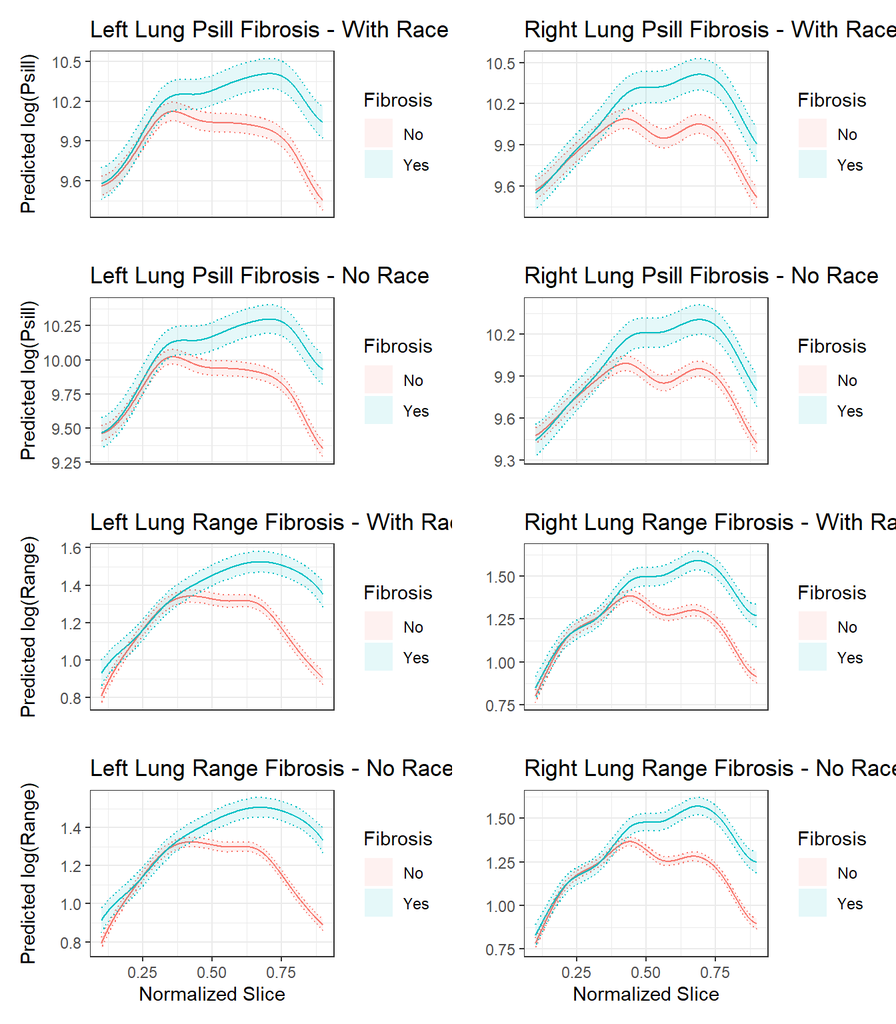

### Mediastinal Lymphadenopathy (ML)

Summary of Models for Mediastinal Lymphadenopathy (ML)

| Term | Left Lung Estimate | Left Lung SE | Left Lung P-Value | Left Lung EDF | Left Lung Ref. DF | Right Lung Estimate | Right Lung SE | Right Lung P-Value | Right Lung EDF | Right Lung Ref. DF |
| --- | --- | --- | --- | --- | --- | --- | --- | --- | --- | --- |
| **Outcome: Psill \| With Race** |  |  |  |  |  |  |  |  |  |  |
| Intercept | 10.16950 | 0.41337 | <2e-16 | NA | NA | 9.90487 | 0.40554 | <2e-16 | NA | NA |
| BMI | 0.00117 | 0.00257 | 0.6 | NA | NA | 0.00176 | 0.00253 | 0.487 | NA | NA |
| Age | 0.00139 | 0.00173 | 0.4 | NA | NA | 0.00263 | 0.00170 | 0.121 | NA | NA |
| Male | 0.00112 | 0.04500 | 1.0 | NA | NA | 0.02013 | 0.04415 | 0.648 | NA | NA |
| Height | -0.00556 | 0.00560 | 0.3 | NA | NA | -0.00319 | 0.00550 | 0.562 | NA | NA |
| Other Races | -0.09654 | 0.06981 | 0.2 | NA | NA | -0.09626 | 0.06849 | 0.160 | NA | NA |
| Non-Hispanic White | -0.15576 | 0.03932 | 7e-05 | NA | NA | -0.15506 | 0.03858 | 6e-05 | NA | NA |
| s(Slice) | NA | NA | <2e-16 | 8.47249 | 8.87652 | NA | NA | <2e-16 | 8.36743 | 8.83040 |
| s(ID) | NA | NA | <2e-16 | 307.60405 | 312.00000 | NA | NA | <2e-16 | 307.10810 | 312.00000 |
| s(Slice):ML | NA | NA | 2e-05 | 4.99084 | 5.75240 | NA | NA | 0.005 | 2.00109 | 2.00218 |
| **Outcome: Psill \| Without Race** |  |  |  |  |  |  |  |  |  |  |
| Intercept | 9.92039 | 0.41715 | <2e-16 | NA | NA | 9.65681 | 0.40954 | <2e-16 | NA | NA |
| BMI | 0.00248 | 0.00262 | 0.3 | NA | NA | 0.00306 | 0.00257 | 0.23 | NA | NA |
| Age | 0.00121 | 0.00177 | 0.5 | NA | NA | 0.00245 | 0.00174 | 0.16 | NA | NA |
| Male | -0.03173 | 0.04504 | 0.5 | NA | NA | -0.01258 | 0.04421 | 0.78 | NA | NA |
| Height | -0.00370 | 0.00571 | 0.5 | NA | NA | -0.00133 | 0.00560 | 0.81 | NA | NA |
| s(Slice) | NA | NA | <2e-16 | 8.47244 | 8.87650 | NA | NA | <2e-16 | 8.36747 | 8.83042 |
| s(ID) | NA | NA | <2e-16 | 309.78427 | 314.00000 | NA | NA | <2e-16 | 309.31517 | 314.00000 |
| s(Slice):ML | NA | NA | 2e-05 | 4.99142 | 5.75303 | NA | NA | 0.01 | 2.00033 | 2.00067 |
| **Outcome: Range \| With Race** |  |  |  |  |  |  |  |  |  |  |
| Intercept | 1.24432 | 0.19480 | 2e-10 | NA | NA | 1.31210 | 0.19230 | 9e-12 | NA | NA |
| BMI | -0.00236 | 0.00121 | 0.05 | NA | NA | -0.00275 | 0.00120 | 0.02 | NA | NA |
| Age | 0.00072 | 0.00081 | 0.38 | NA | NA | 0.00142 | 0.00080 | 0.08 | NA | NA |
| Male | 0.03686 | 0.02121 | 0.08 | NA | NA | 0.02425 | 0.02094 | 0.25 | NA | NA |
| Height | -0.00026 | 0.00264 | 0.92 | NA | NA | -0.00157 | 0.00261 | 0.55 | NA | NA |
| Other Races | 0.01014 | 0.03290 | 0.76 | NA | NA | -0.01738 | 0.03247 | 0.59 | NA | NA |
| Non-Hispanic White | -0.02442 | 0.01853 | 0.19 | NA | NA | -0.02648 | 0.01829 | 0.15 | NA | NA |
| s(Slice) | NA | NA | <2e-16 | 7.62598 | 8.27083 | NA | NA | <2e-16 | 8.53294 | 8.90547 |
| s(ID) | NA | NA | <2e-16 | 296.40718 | 312.00000 | NA | NA | <2e-16 | 296.28256 | 312.00000 |
| s(Slice):ML | NA | NA | <2e-16 | 4.72761 | 5.45831 | NA | NA | 4e-08 | 3.62355 | 4.19630 |
| **Outcome: Range \| Without Race** |  |  |  |  |  |  |  |  |  |  |
| Intercept | 1.21648 | 0.19269 | 3e-10 | NA | NA | 1.26931 | 0.19005 | 2e-11 | NA | NA |
| BMI | -0.00213 | 0.00121 | 0.08 | NA | NA | -0.00253 | 0.00119 | 0.03 | NA | NA |
| Age | 0.00066 | 0.00082 | 0.42 | NA | NA | 0.00139 | 0.00081 | 0.08 | NA | NA |
| Male | 0.03340 | 0.02080 | 0.11 | NA | NA | 0.01860 | 0.02052 | 0.36 | NA | NA |
| Height | -0.00011 | 0.00264 | 0.97 | NA | NA | -0.00125 | 0.00260 | 0.63 | NA | NA |
| s(Slice) | NA | NA | <2e-16 | 7.62600 | 8.27085 | NA | NA | <2e-16 | 8.53294 | 8.90547 |
| s(ID) | NA | NA | <2e-16 | 298.43738 | 314.00000 | NA | NA | <2e-16 | 298.28522 | 314.00000 |
| s(Slice):ML | NA | NA | <2e-16 | 4.72784 | 5.45857 | NA | NA | <2e-16 | 3.62362 | 4.19638 |

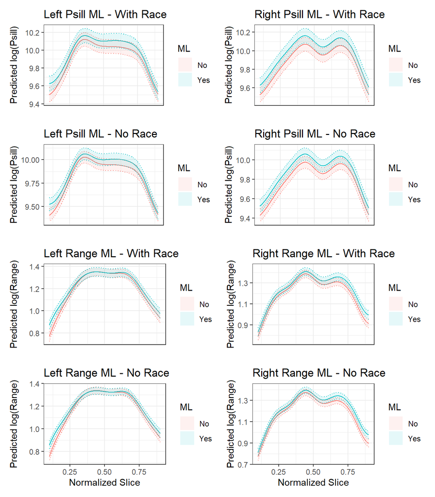

### Traction Bronchiectasis (TB)

Summary of Models for Traction Bronchiectasis (TB)

| Term | Left Lung Estimate | Left Lung SE | Left Lung P-Value | Left Lung EDF | Left Lung Ref. DF | Right Lung Estimate | Right Lung SE | Right Lung P-Value | Right Lung EDF | Right Lung Ref. DF |
| --- | --- | --- | --- | --- | --- | --- | --- | --- | --- | --- |
| **Outcome: Psill \| With Race** |  |  |  |  |  |  |  |  |  |  |
| Intercept | 10.00629 | 0.37176 | <2e-16 | NA | NA | 9.77195 | 0.36387 | <2e-16 | NA | NA |
| BMI | 0.00440 | 0.00235 | 0.061 | NA | NA | 0.00502 | 0.00230 | 0.029 | NA | NA |
| Age | -0.00028 | 0.00156 | 0.858 | NA | NA | 0.00110 | 0.00153 | 0.473 | NA | NA |
| Male | 0.00961 | 0.04035 | 0.812 | NA | NA | 0.03281 | 0.03949 | 0.406 | NA | NA |
| Height | -0.00505 | 0.00503 | 0.316 | NA | NA | -0.00311 | 0.00492 | 0.528 | NA | NA |
| Other Races | -0.03498 | 0.06315 | 0.580 | NA | NA | -0.03008 | 0.06181 | 0.626 | NA | NA |
| Non-Hispanic White | -0.10720 | 0.03573 | 0.003 | NA | NA | -0.10316 | 0.03497 | 0.003 | NA | NA |
| s(Slice) | NA | NA | <2e-16 | 8.51344 | 8.89502 | NA | NA | <2e-16 | 8.49022 | 8.85635 |
| s(ID) | NA | NA | <2e-16 | 306.85332 | 312.00000 | NA | NA | <2e-16 | 306.22110 | 312.00000 |
| s(Slice):TB | NA | NA | <2e-16 | 5.37064 | 6.16631 | NA | NA | <2e-16 | 8.06327 | 8.71701 |
| **Outcome: Psill \| Without Race** |  |  |  |  |  |  |  |  |  |  |
| Intercept | 9.83577 | 0.37065 | <2e-16 | NA | NA | 9.60955 | 0.36267 | <2e-16 | NA | NA |
| BMI | 0.00548 | 0.00236 | 0.02 | NA | NA | 0.00606 | 0.00231 | 0.009 | NA | NA |
| Age | -0.00056 | 0.00158 | 0.72 | NA | NA | 0.00083 | 0.00155 | 0.593 | NA | NA |
| Male | -0.01114 | 0.03995 | 0.78 | NA | NA | 0.01308 | 0.03909 | 0.738 | NA | NA |
| Height | -0.00384 | 0.00507 | 0.45 | NA | NA | -0.00196 | 0.00496 | 0.692 | NA | NA |
| s(Slice) | NA | NA | <2e-16 | 8.51341 | 8.89500 | NA | NA | <2e-16 | 8.49027 | 8.85636 |
| s(ID) | NA | NA | <2e-16 | 308.97280 | 314.00000 | NA | NA | <2e-16 | 308.35171 | 314.00000 |
| s(Slice):TB | NA | NA | <2e-16 | 5.37091 | 6.16659 | NA | NA | <2e-16 | 8.06386 | 8.71756 |
| **Outcome: Range \| With Race** |  |  |  |  |  |  |  |  |  |  |
| Intercept | 1.17968 | 0.18123 | 8e-11 | NA | NA | 1.26386 | 0.17901 | 2e-12 | NA | NA |
| BMI | -0.00109 | 0.00115 | 0.34 | NA | NA | -0.00147 | 0.00113 | 0.2 | NA | NA |
| Age | 0.00006 | 0.00076 | 0.94 | NA | NA | 0.00084 | 0.00075 | 0.3 | NA | NA |
| Male | 0.04017 | 0.01967 | 0.04 | NA | NA | 0.02978 | 0.01943 | 0.1 | NA | NA |
| Height | -0.00005 | 0.00245 | 0.98 | NA | NA | -0.00160 | 0.00242 | 0.5 | NA | NA |
| Other Races | 0.03434 | 0.03078 | 0.26 | NA | NA | 0.00918 | 0.03041 | 0.8 | NA | NA |
| Non-Hispanic White | -0.00533 | 0.01742 | 0.76 | NA | NA | -0.00568 | 0.01720 | 0.7 | NA | NA |
| s(Slice) | NA | NA | <2e-16 | 7.68792 | 8.32766 | NA | NA | <2e-16 | 8.57290 | 8.91199 |
| s(ID) | NA | NA | <2e-16 | 294.96882 | 312.00000 | NA | NA | <2e-16 | 294.79186 | 312.00000 |
| s(Slice):TB | NA | NA | <2e-16 | 6.43847 | 7.25602 | NA | NA | <2e-16 | 6.65660 | 7.46279 |
| **Outcome: Range \| Without Race** |  |  |  |  |  |  |  |  |  |  |
| Intercept | 1.18833 | 0.17857 | 3e-11 | NA | NA | 1.26006 | 0.17592 | 8e-13 | NA | NA |
| BMI | -0.00101 | 0.00114 | 0.38 | NA | NA | -0.00141 | 0.00112 | 0.2 | NA | NA |
| Age | 0.00001 | 0.00076 | 0.99 | NA | NA | 0.00081 | 0.00075 | 0.3 | NA | NA |
| Male | 0.04158 | 0.01925 | 0.03 | NA | NA | 0.02942 | 0.01896 | 0.1 | NA | NA |
| Height | -0.00020 | 0.00244 | 0.93 | NA | NA | -0.00160 | 0.00241 | 0.5 | NA | NA |
| s(Slice) | NA | NA | <2e-16 | 7.68791 | 8.32765 | NA | NA | <2e-16 | 8.57291 | 8.91200 |
| s(ID) | NA | NA | <2e-16 | 296.96717 | 314.00000 | NA | NA | <2e-16 | 296.70074 | 314.00000 |
| s(Slice):TB | NA | NA | <2e-16 | 6.43863 | 7.25618 | NA | NA | <2e-16 | 6.65665 | 7.46284 |

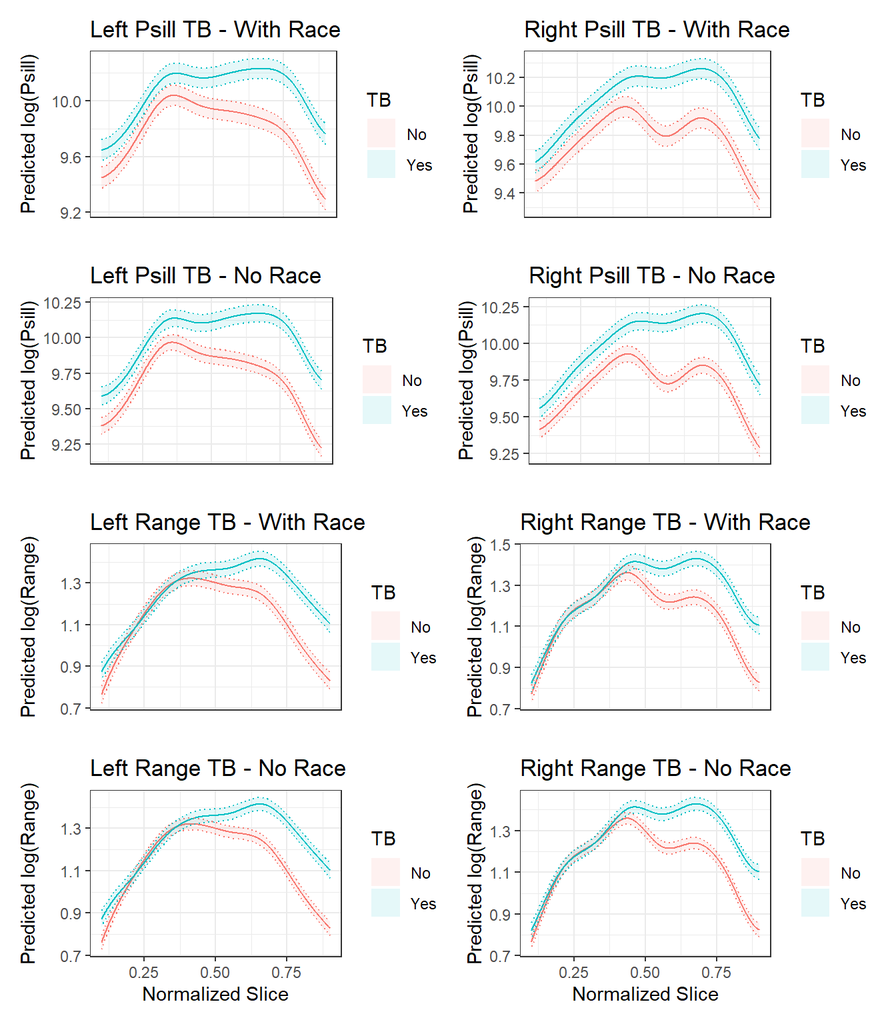

### FEV1

Summary of Models for FEV1

| Term | Left Lung Estimate | Left Lung SE | Left Lung P-Value | Left Lung EDF | Left Lung Ref. DF | Right Lung Estimate | Right Lung SE | Right Lung P-Value | Right Lung EDF | Right Lung Ref. DF |
| --- | --- | --- | --- | --- | --- | --- | --- | --- | --- | --- |
| **Outcome: Psill \| With Race** |  |  |  |  |  |  |  |  |  |  |
| Intercept | 10.04239 | 0.36986 | <2e-16 | NA | NA | 9.82668 | 0.37014 | <2e-16 | NA | NA |
| BMI | 0.00028 | 0.00231 | 0.903 | NA | NA | 0.00085 | 0.00231 | 0.713 | NA | NA |
| Age | -0.00450 | 0.00169 | 0.008 | NA | NA | -0.00267 | 0.00169 | 0.114 | NA | NA |
| Male | 0.11603 | 0.04187 | 0.006 | NA | NA | 0.13256 | 0.04190 | 0.002 | NA | NA |
| Height | 0.00789 | 0.00525 | 0.133 | NA | NA | 0.00889 | 0.00526 | 0.091 | NA | NA |
| Other Races | -0.02708 | 0.06296 | 0.667 | NA | NA | -0.02761 | 0.06300 | 0.661 | NA | NA |
| Non-Hispanic White | -0.04349 | 0.03719 | 0.242 | NA | NA | -0.04736 | 0.03722 | 0.203 | NA | NA |
| s(Slice) | NA | NA | <2e-16 | 8.30046 | 8.74502 | NA | NA | <2e-16 | 5.90979 | 6.67744 |
| s(ID) | NA | NA | <2e-16 | 306.59394 | 312.00000 | NA | NA | <2e-16 | 306.20319 | 312.00000 |
| s(Slice):FEV1 | NA | NA | <2e-16 | 5.69606 | 6.49358 | NA | NA | <2e-16 | 8.93362 | 9.45753 |
| **Outcome: Psill \| Without Race** |  |  |  |  |  |  |  |  |  |  |
| Intercept | 9.96901 | 0.36398 | <2e-16 | NA | NA | 9.74764 | 0.36441 | <2e-16 | NA | NA |
| BMI | 0.00058 | 0.00230 | 0.801 | NA | NA | 0.00118 | 0.00230 | 0.608 | NA | NA |
| Age | -0.00482 | 0.00167 | 0.004 | NA | NA | -0.00302 | 0.00167 | 0.070 | NA | NA |
| Male | 0.11196 | 0.04156 | 0.007 | NA | NA | 0.12828 | 0.04161 | 0.002 | NA | NA |
| Height | 0.00899 | 0.00517 | 0.082 | NA | NA | 0.01008 | 0.00517 | 0.051 | NA | NA |
| s(Slice) | NA | NA | <2e-16 | 8.30036 | 8.74494 | NA | NA | <2e-16 | 5.90980 | 6.67746 |
| s(ID) | NA | NA | <2e-16 | 308.58259 | 314.00000 | NA | NA | <2e-16 | 308.19578 | 314.00000 |
| s(Slice):FEV1 | NA | NA | <2e-16 | 5.69657 | 6.49411 | NA | NA | <2e-16 | 8.93368 | 9.45757 |
| **Outcome: Range \| With Race** |  |  |  |  |  |  |  |  |  |  |
| Intercept | 1.18577 | 0.17724 | 2e-11 | NA | NA | 1.27623 | 0.17738 | 7e-13 | NA | NA |
| BMI | -0.00274 | 0.00111 | 0.01 | NA | NA | -0.00316 | 0.00111 | 0.004 | NA | NA |
| Age | -0.00186 | 0.00081 | 0.02 | NA | NA | -0.00095 | 0.00081 | 0.242 | NA | NA |
| Male | 0.08645 | 0.02007 | 2e-05 | NA | NA | 0.07425 | 0.02008 | 2e-04 | NA | NA |
| Height | 0.00563 | 0.00252 | 0.03 | NA | NA | 0.00383 | 0.00252 | 0.129 | NA | NA |
| Other Races | 0.04005 | 0.03017 | 0.18 | NA | NA | 0.01313 | 0.03019 | 0.664 | NA | NA |
| Non-Hispanic White | 0.02419 | 0.01782 | 0.17 | NA | NA | 0.02146 | 0.01784 | 0.229 | NA | NA |
| s(Slice) | NA | NA | <2e-16 | 7.40982 | 8.06188 | NA | NA | <2e-16 | 8.32629 | 8.74448 |
| s(ID) | NA | NA | <2e-16 | 293.50107 | 312.00000 | NA | NA | <2e-16 | 293.86043 | 312.00000 |
| s(Slice):FEV1 | NA | NA | <2e-16 | 4.84094 | 5.56381 | NA | NA | <2e-16 | 6.10298 | 6.90849 |
| **Outcome: Range \| Without Race** |  |  |  |  |  |  |  |  |  |  |
| Intercept | 1.23809 | 0.17473 | 1e-12 | NA | NA | 1.31233 | 0.17459 | 6e-14 | NA | NA |
| BMI | -0.00289 | 0.00111 | 0.009 | NA | NA | -0.00330 | 0.00110 | 0.003 | NA | NA |
| Age | -0.00172 | 0.00080 | 0.032 | NA | NA | -0.00079 | 0.00080 | 0.324 | NA | NA |
| Male | 0.09064 | 0.01995 | 6e-06 | NA | NA | 0.07624 | 0.01993 | 1e-04 | NA | NA |
| Height | 0.00489 | 0.00248 | 0.049 | NA | NA | 0.00328 | 0.00248 | 0.185 | NA | NA |
| s(Slice) | NA | NA | <2e-16 | 7.40974 | 8.06180 | NA | NA | <2e-16 | 8.32619 | 8.74440 |
| s(ID) | NA | NA | <2e-16 | 295.52728 | 314.00000 | NA | NA | <2e-16 | 295.82713 | 314.00000 |
| s(Slice):FEV1 | NA | NA | <2e-16 | 4.84119 | 5.56408 | NA | NA | <2e-16 | 6.10342 | 6.90893 |

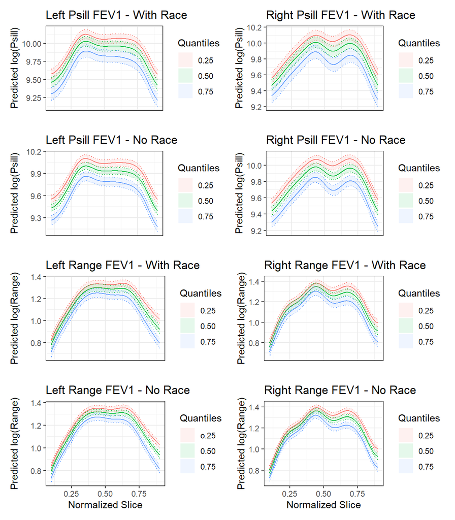

### FVC

Summary of Models for FVC

| Term | Left Lung Estimate | Left Lung SE | Left Lung P-Value | Left Lung EDF | Left Lung Ref. DF | Right Lung Estimate | Right Lung SE | Right Lung P-Value | Right Lung EDF | Right Lung Ref. DF |
| --- | --- | --- | --- | --- | --- | --- | --- | --- | --- | --- |
| **Outcome: Psill \| With Race** |  |  |  |  |  |  |  |  |  |  |
| Intercept | 9.66089 | 0.35733 | <2e-16 | NA | NA | 9.42400 | 0.34952 | <2e-16 | NA | NA |
| BMI | -0.00114 | 0.00222 | 0.607 | NA | NA | -0.00065 | 0.00217 | 0.76 | NA | NA |
| Age | -0.00488 | 0.00159 | 0.002 | NA | NA | -0.00354 | 0.00156 | 0.02 | NA | NA |
| Male | 0.16951 | 0.04117 | 4e-05 | NA | NA | 0.19513 | 0.04027 | 1e-06 | NA | NA |
| Height | 0.01748 | 0.00527 | 9e-04 | NA | NA | 0.01974 | 0.00516 | 1e-04 | NA | NA |
| Other Races | 0.02586 | 0.06082 | 0.671 | NA | NA | 0.03104 | 0.05949 | 0.60 | NA | NA |
| Non-Hispanic White | -0.00873 | 0.03617 | 0.809 | NA | NA | -0.00369 | 0.03538 | 0.92 | NA | NA |
| s(Slice) | NA | NA | <2e-16 | 8.40892 | 8.82473 | NA | NA | <2e-16 | 5.86866 | 6.63514 |
| s(ID) | NA | NA | <2e-16 | 306.06383 | 312.00000 | NA | NA | <2e-16 | 305.35883 | 312.00000 |
| s(Slice):FVC | NA | NA | <2e-16 | 4.75602 | 5.48317 | NA | NA | <2e-16 | 8.68093 | 9.25958 |
| **Outcome: Psill \| Without Race** |  |  |  |  |  |  |  |  |  |  |
| Intercept | 9.65835 | 0.34899 | <2e-16 | NA | NA | 9.43234 | 0.34133 | <2e-16 | NA | NA |
| BMI | -0.00106 | 0.00221 | 0.631 | NA | NA | -0.00060 | 0.00216 | 0.78 | NA | NA |
| Age | -0.00497 | 0.00157 | 0.002 | NA | NA | -0.00360 | 0.00154 | 0.02 | NA | NA |
| Male | 0.17118 | 0.04100 | 3e-05 | NA | NA | 0.19715 | 0.04010 | 9e-07 | NA | NA |
| Height | 0.01757 | 0.00512 | 6e-04 | NA | NA | 0.01965 | 0.00501 | 9e-05 | NA | NA |
| s(Slice) | NA | NA | <2e-16 | 8.31987 | 8.73880 | NA | NA | <2e-16 | 5.86866 | 6.63514 |
| s(ID) | NA | NA | <2e-16 | 308.03504 | 314.00000 | NA | NA | <2e-16 | 307.32504 | 314.00000 |
| s(Slice):FVC | NA | NA | <2e-16 | 5.11245 | 5.98174 | NA | NA | <2e-16 | 8.68095 | 9.25960 |
| **Outcome: Range \| With Race** |  |  |  |  |  |  |  |  |  |  |
| Intercept | 1.10584 | 0.18673 | 3e-09 | NA | NA | 1.17425 | 0.18289 | 1e-10 | NA | NA |
| BMI | -0.00303 | 0.00116 | 0.009 | NA | NA | -0.00353 | 0.00114 | 0.002 | NA | NA |
| Age | -0.00104 | 0.00083 | 0.212 | NA | NA | -0.00045 | 0.00082 | 0.583 | NA | NA |
| Male | 0.08600 | 0.02151 | 6e-05 | NA | NA | 0.08075 | 0.02107 | 1e-04 | NA | NA |
| Height | 0.00625 | 0.00276 | 0.023 | NA | NA | 0.00546 | 0.00270 | 0.043 | NA | NA |
| Other Races | 0.04587 | 0.03178 | 0.149 | NA | NA | 0.02376 | 0.03113 | 0.445 | NA | NA |
| Non-Hispanic White | 0.01817 | 0.01890 | 0.336 | NA | NA | 0.02187 | 0.01851 | 0.237 | NA | NA |
| s(Slice) | NA | NA | <2e-16 | 7.47676 | 8.12238 | NA | NA | <2e-16 | 8.51501 | 8.88845 |
| s(ID) | NA | NA | <2e-16 | 294.84587 | 312.00000 | NA | NA | <2e-16 | 294.50475 | 312.00000 |
| s(Slice):FVC | NA | NA | <2e-16 | 4.99693 | 5.73112 | NA | NA | <2e-16 | 3.99263 | 4.62274 |
| **Outcome: Range \| Without Race** |  |  |  |  |  |  |  |  |  |  |
| Intercept | 1.15781 | 0.18286 | 2e-10 | NA | NA | 1.22208 | 0.17889 | 9e-12 | NA | NA |
| BMI | -0.00310 | 0.00116 | 0.008 | NA | NA | -0.00364 | 0.00113 | 0.001 | NA | NA |
| Age | -0.00094 | 0.00082 | 0.255 | NA | NA | -0.00030 | 0.00081 | 0.714 | NA | NA |
| Male | 0.08900 | 0.02149 | 3e-05 | NA | NA | 0.08232 | 0.02102 | 9e-05 | NA | NA |
| Height | 0.00544 | 0.00268 | 0.043 | NA | NA | 0.00468 | 0.00263 | 0.075 | NA | NA |
| s(Slice) | NA | NA | <2e-16 | 7.47672 | 8.12234 | NA | NA | <2e-16 | 8.51500 | 8.88844 |
| s(ID) | NA | NA | <2e-16 | 296.85386 | 314.00000 | NA | NA | <2e-16 | 296.47259 | 314.00000 |
| s(Slice):FVC | NA | NA | <2e-16 | 4.99731 | 5.73153 | NA | NA | <2e-16 | 3.99292 | 4.62308 |

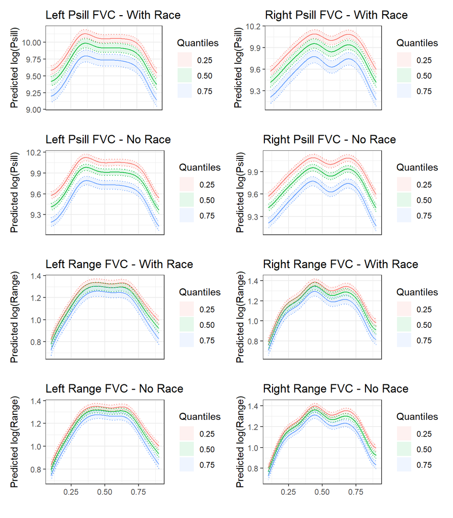

### FEV1/FVC

Summary of Models for FEV1/FVC

| Term | Left Lung Estimate | Left Lung SE | Left Lung P-Value | Left Lung EDF | Left Lung Ref. DF | Right Lung Estimate | Right Lung SE | Right Lung P-Value | Right Lung EDF | Right Lung Ref. DF |
| --- | --- | --- | --- | --- | --- | --- | --- | --- | --- | --- |
| **Outcome: Psill \| With Race** |  |  |  |  |  |  |  |  |  |  |
| Intercept | 10.46161 | 0.43697 | <2e-16 | NA | NA | 10.06222 | 0.43335 | <2e-16 | NA | NA |
| BMI | 0.00135 | 0.00259 | 0.6 | NA | NA | 0.00164 | 0.00257 | 0.52 | NA | NA |
| Age | 0.00132 | 0.00174 | 0.5 | NA | NA | 0.00310 | 0.00173 | 0.07 | NA | NA |
| Male | 0.00854 | 0.04487 | 0.8 | NA | NA | 0.03237 | 0.04450 | 0.47 | NA | NA |
| Height | -0.00704 | 0.00560 | 0.2 | NA | NA | -0.00472 | 0.00556 | 0.40 | NA | NA |
| Other Races | -0.09313 | 0.06990 | 0.2 | NA | NA | -0.08754 | 0.06932 | 0.21 | NA | NA |
| Non-Hispanic White | -0.14955 | 0.03935 | 1e-04 | NA | NA | -0.14818 | 0.03903 | 1e-04 | NA | NA |
| s(Slice) | NA | NA | <2e-16 | 8.28304 | 8.71098 | NA | NA | <2e-16 | 6.01842 | 6.70441 |
| s(ID) | NA | NA | <2e-16 | 307.70117 | 312.00000 | NA | NA | <2e-16 | 307.29931 | 312.00000 |
| s(Slice):FEV1/FVC | NA | NA | <2e-16 | 4.48937 | 5.16254 | NA | NA | <2e-16 | 8.41966 | 8.93198 |
| **Outcome: Psill \| Without Race** |  |  |  |  |  |  |  |  |  |  |
| Intercept | 10.23216 | 0.44057 | <2e-16 | NA | NA | 9.83754 | 0.43694 | <2e-16 | NA | NA |
| BMI | 0.00265 | 0.00262 | 0.3 | NA | NA | 0.00294 | 0.00260 | 0.3 | NA | NA |
| Age | 0.00106 | 0.00178 | 0.6 | NA | NA | 0.00284 | 0.00177 | 0.1 | NA | NA |
| Male | -0.02425 | 0.04473 | 0.6 | NA | NA | 0.00021 | 0.04436 | 1.0 | NA | NA |
| Height | -0.00518 | 0.00569 | 0.4 | NA | NA | -0.00290 | 0.00564 | 0.6 | NA | NA |
| s(Slice) | NA | NA | <2e-16 | 8.28206 | 8.71013 | NA | NA | <2e-16 | 6.01875 | 6.70471 |
| s(ID) | NA | NA | <2e-16 | 309.86187 | 314.00000 | NA | NA | <2e-16 | 309.47564 | 314.00000 |
| s(Slice):FEV1/FVC | NA | NA | <2e-16 | 4.49372 | 5.16732 | NA | NA | <2e-16 | 8.41996 | 8.93219 |
| **Outcome: Range \| With Race** |  |  |  |  |  |  |  |  |  |  |
| Intercept | 1.65070 | 0.19624 | <2e-16 | NA | NA | 1.65049 | 0.19916 | <2e-16 | NA | NA |
| BMI | -0.00189 | 0.00116 | 0.10 | NA | NA | -0.00244 | 0.00118 | 0.04 | NA | NA |
| Age | 0.00009 | 0.00078 | 0.91 | NA | NA | 0.00107 | 0.00080 | 0.18 | NA | NA |
| Male | 0.03863 | 0.02015 | 0.06 | NA | NA | 0.02857 | 0.02045 | 0.16 | NA | NA |
| Height | -0.00156 | 0.00252 | 0.54 | NA | NA | -0.00291 | 0.00255 | 0.25 | NA | NA |
| Other Races | 0.00775 | 0.03139 | 0.80 | NA | NA | -0.01698 | 0.03186 | 0.59 | NA | NA |
| Non-Hispanic White | -0.01945 | 0.01767 | 0.27 | NA | NA | -0.02112 | 0.01794 | 0.24 | NA | NA |
| s(Slice) | NA | NA | <2e-16 | 3.80697 | 4.46480 | NA | NA | <2e-16 | 4.89104 | 5.63889 |
| s(ID) | NA | NA | <2e-16 | 295.31996 | 312.00000 | NA | NA | <2e-16 | 295.85900 | 312.00000 |
| s(Slice):FEV1/FVC | NA | NA | <2e-16 | 7.89890 | 8.55097 | NA | NA | <2e-16 | 9.10318 | 9.49995 |
| **Outcome: Range \| Without Race** |  |  |  |  |  |  |  |  |  |  |
| Intercept | 1.63205 | 0.19406 | <2e-16 | NA | NA | 1.61592 | 0.19681 | 2e-16 | NA | NA |
| BMI | -0.00170 | 0.00115 | 0.14 | NA | NA | -0.00226 | 0.00117 | 0.05 | NA | NA |
| Age | 0.00003 | 0.00078 | 0.97 | NA | NA | 0.00104 | 0.00080 | 0.19 | NA | NA |
| Male | 0.03573 | 0.01970 | 0.07 | NA | NA | 0.02368 | 0.01998 | 0.24 | NA | NA |
| Height | -0.00144 | 0.00251 | 0.57 | NA | NA | -0.00262 | 0.00254 | 0.30 | NA | NA |
| s(Slice) | NA | NA | <2e-16 | 3.80698 | 4.46483 | NA | NA | <2e-16 | 4.89106 | 5.63891 |
| s(ID) | NA | NA | <2e-16 | 297.30919 | 314.00000 | NA | NA | <2e-16 | 297.82587 | 314.00000 |
| s(Slice):FEV1/FVC | NA | NA | <2e-16 | 7.89900 | 8.55108 | NA | NA | <2e-16 | 9.10317 | 9.49995 |

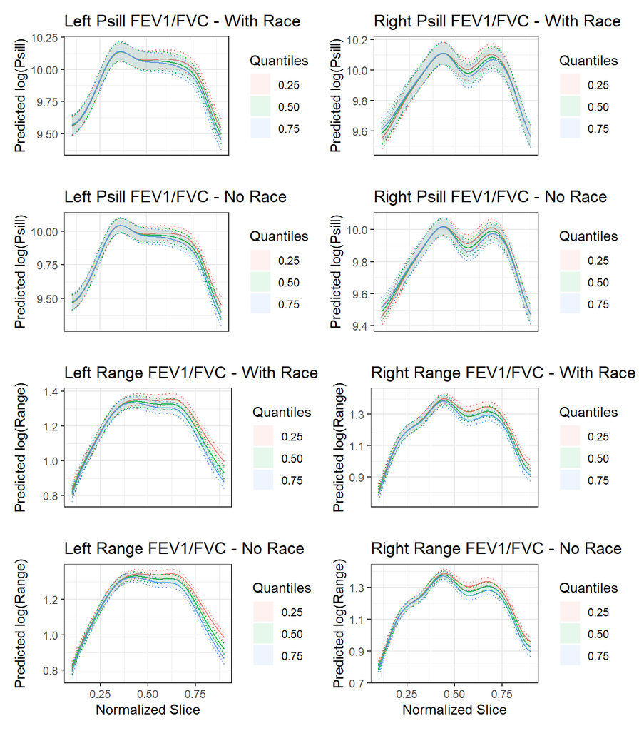